# Plotting Assignment #7

## 4.2 Plot 3: Water Level Change of Individual Wells

Figure 3 shows the same six Colorado aquifers as in Figure 1 and Figure 2, but this time also shows the 40-year water level difference in each individual monitoring wells across the state. The forty year water level difference ranges from -67.67 feet to +71.71 feet across different wells–with one outlier in the Piceance Basin at +244.30 feet–and the average forty year difference across all wells is -7.77 feet. Individual aquifer average difference per year ranges from -17.33 to +14.21 feet: High Plains: -17.33; San Luis: -6.51; Denver: +2.25; Paradox: +7.01; San Juan: -6.71; Piceance: +14.21. Overall, drought conditions in Colorado fluctuate, but seem to be becoming more serious over time. Additionally, this year’s exceptionally low snowpack and limited precipitation will probably have lasting impacts on the state’s water supply, possibly for years to come.

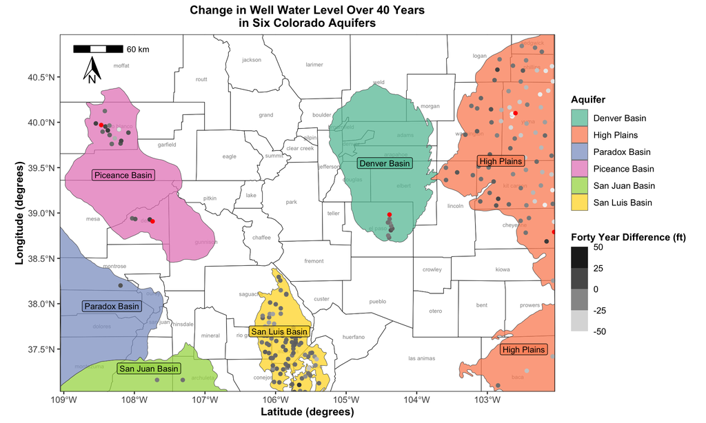

```r
# new df with water level averages in the 1980s per well
water_level_1980s <- water_levels |>
  mutate(year = year(Time)) |> # pulling out year from Time column
  filter(year >= 1980 & year < 1990) |> # filtering between 1980-1990
  summarize(
    # summarizing by well and averaging water level
    .by = c(SiteNo),
    water_level_1980s = mean(water_level.ft, na.rm = TRUE)
  )


# new df with water level averages in the 2010s per well
water_level_2010s <- water_levels |>
  mutate(year = year(Time)) |> # pulling out year from Time column
  filter(year >= 2010 & year < 2020) |> # filtering between 2010-2020
  summarize(
    # summarizing by well and averaging water level
    .by = SiteNo,
    water_level_2010s = mean(water_level.ft, na.rm = TRUE)
  )

# making a new dataframe to be able to put only corresponding aquifer data back into wells_w_water_level_diffs df
well_info <- water_levels |>
  select(SiteNo, aquifer_name) |> # keep SiteNo and aquifer_name
  distinct() # only the unique combos to remove duplicates and ensure smooth joining

wells_info <- wells |> # making new df with just SiteNo and geometry of wells for plot
  select(SiteNo, geometry)

# adding aquifer data back in, joined by SiteNo
wells_w_water_level_diffs <- left_join(
  water_level_1980s,
  water_level_2010s,
  by = "SiteNo"
) |>
  left_join(well_info, by = "SiteNo") |>
  left_join(wells_info, by = "SiteNo") # adding the geometry data back in from the wells_info df which came from the well df

wells_w_water_level_diffs <- wells_w_water_level_diffs |>
  mutate(
    forty_yr_diff = water_level_2010s - water_level_1980s
  )

# calculating average water level gain/drop over forty year
averages <- wells_w_water_level_diffs |>
  summarize(
    .by = "aquifer_name",
    mean_per_aquifer = mean(forty_yr_diff)
  )


# plotting the plot
states |>
  filter(name == "Colorado") |> # filtering states to only Colorado
  ggplot() + # making the plot frame
  geom_sf(
    # adding counties in Colorado geometries; these are the polygons
    data = counties_co,
    aes(geometry = geom),
    color = "black",
    fill = "white",
  ) +
  geom_sf_text(
    # adding county names in Colorado that correspond to the polygons in the layer above
    data = counties_co,
    aes(label = county), # setting the label to be county
    size = 2, # making the text smaller
    alpha = 0.5 # setting the text to be a little transparent so they're easier to ignore/the plot is less busy
  ) +
  geom_sf(
    data = filtered_aquifers, # plotting only aquifers with monitoring wells
    aes(geometry = geometry, fill = NAME), # setting the geometry to be the geometry column, filling (color fill) by name
    alpha = 0.75 # setting opacity
  ) +
  geom_sf(
    # plotting differences in well water level from 1980-2020
    data = wells_w_water_level_diffs, # setting dataframe to pull data from
    aes(geometry = geometry, color = forty_yr_diff) # setting geometry to be the geometry column, and the color to be the difference between 1980s average and 2010s average
  ) +
  scale_color_gradient(
    # customizing the color gradient
    low = "#ffffff", # making the low white
    high = "#000000", # making the high black
    limits = c(-50, 50), # setting the lower and upper limits of the scale
    #midpoint = 0, # not necessary if not doing gradient2 since it is a continuous scale
    na.value = "red" # setting the well locations with no data to be red points
  ) +
  geom_sf_label(
    # adding aquifer labels
    data = filtered_aquifers, # setting the dataframe to pull data frame
    aes(label = NAME, fill = NAME), # labeling the aquifers and filling the label with a color according to its name
    color = "black", # color of the outline
    size = 3, # making the text smaller
    alpha = 0.75, # text box opacity
    show.legend = FALSE, # removing legend from this so that the aquifer only has one entry
  ) +
  scale_fill_brewer(palette = "Set2") + # using colorblind friendly palette
  guides(color = guide_colorsteps(show.limits = TRUE)) + # showing upper and lower limit of scale
  annotation_scale(
    # adding a scale bar
    location = "tl", # top left location
    width_hint = 0.1, # making scale bar narrower so it doesn't take up as much room
    pad_x = unit(0.5, "cm"), # adding space between the top edge of the plot and the scale bar
    pad_y = unit(0.4, "cm") # adding space between the left edge of the plot and the scale bar
  ) +
  annotation_north_arrow(
    # adding a north arrow
    style = north_arrow_orienteering(), # specifying north arrow type/design
    location = "tl", # top left location
    height = unit(0.07, "npc"), #making the north arrow shorter to take up less room
    width = unit(0.035, "npc"), # making the north arrow narrower
    pad_x = unit(0.85, "cm"), # adding space between left edge of plot and north arrow, centering underneath scale bar
    pad_y = unit(0.8, "cm") # adding space between top edge of plot and north arrow, ensuring underneath scale bar
  ) +
  coord_sf(
    # cropping the plot to the edge of the data frame
    xlim = c(co_bbox["xmin"] + 0.31, co_bbox["xmax"] - 0.32),
    ylim = c(co_bbox["ymin"] + 0.21, co_bbox["ymax"] - 0.21)
  ) +
  theme_bw() +
  labs(
    # changing labels for x/y axes, title, and legend titles
    x = "Latitude (degrees)",
    y = "Longitude (degrees)",
    title = "Change in Well Water Level Over 40 Years\nin Six Colorado Aquifers",
    color = "Forty Year Difference (ft)",
    fill = "Aquifer"
  ) +
  theme(
    # customizing the plot
    plot.title = element_text(hjust = 0.5, size = 12, face = "bold"), # centering, sizing, and bolding title
    axis.title = element_text(size = 11, face = "bold"), # sizing and bolding axis titles
    legend.title = element_text(size = 10, face = "bold"), # sizing and bolding legend titles
    axis.text = element_text(size = 9), # sizing axis text
    legend.text = element_text(size = 9) # sizing legend text
  )
```

# 5 References

R Core Team (2022) *[R: A language and environment for statistical computing](https://www.R-project.org/)*. R Foundation for Statistical Computing, Vienna, Austria.

Ruybal, C.J., Hogue, T.S., McCray, J.E. (2019) [Assessment of groundwater depletion and implications for management in the denver basin aquifer system](https://doi.org/10.1111/1752-1688.12755). *JAWRA Journal of the American Water Resources Association* 55, 1130–1148.

Wickham, H. *et al.* (2019) [Welcome to the tidyverse](https://doi.org/10.21105/joss.01686). *Journal of Open Source Software* 4, 1686.